# Making the cut

## Introduction

This post is entirely inspired by the great series of tutorials explaining bayesian estimation methods using baseball data by David Robinson at his blog, Variance Explained.

Using David’s post on [emperical bayes](http://varianceexplained.org/r/empirical_bayes_baseball) as a guide, I am going to explore the question: how likely is a golfer to make the cut at The Masters? The Masters tournament is a prestigious event (1 of 4 majors played every year) with a very competitive field of players.

### The cut

A typical golf tournament consists of 4 rounds of 18 holes. After the first two rounds of play, the bottom 30%-60% of of players on the leaderboard are “cut” from the tournament. The top 40%-70% of the leaderboard play an additional 2 rounds to determine the winner. The cut line varies by tournament, however, it’s usually the top 70 players and ties make it to the weekend round.In my example today I will be using the Masters tournament where cut line is a little more complicated. To make the cut in the masters, a player must either finish in the top 50 players and ties or be within 10 shots of the leader.

A useful question to explore is, who has had the best success in terms of making the cut at a given tournament, and does this past success predict future success.

## The data

The Masters has been played every April since 1934 at the same golf course; Augusta National in Augusta, Georgia. The PGA Tour website keeps easily accessible records of players performance at the Masters since 1972. The following function will be used to scrape the PGA Tour website for that data. It has flexible arguments for tournament id in case you want tournament other than the Masters, as well as the years to be extracted.

```r
# tournament history function ---------------------------------------------

fetch_history <- function(tourn_id = "014", year_end = 2015, num_years = 5) {
  require(jsonlite)
  require(dplyr)

  url_seed <- "http://www.pgatour.com/data/r/"

  years <- (year_end - num_years + 1) : year_end
  j <- 1

  df <- vector("list", length = length(years))

  # loop over each year
  for (i in years) {

    url_tourn_yr <- paste0(url_seed, tourn_id,"/",i,"/tournsum.json")

    dat <- fromJSON(url_tourn_yr)

    players <- dat$years$tours[[1]]$trns[[1]]$plrs[[1]]$name
    position <- dat$years$tours[[1]]$trns[[1]]$plrs[[1]]$finPos

    df[[j]] <- cbind(players, position)
    df[[j]]$player_name <- paste(df[[j]]$first, df[[j]]$last)
    df[[j]]$year <- i
    df[[j]]$made_cut <- ifelse(df[[j]]$finPosValue == "CUT", 0, 1)
    df[[j]] <- df[[j]] %>%  select(player_name, year, position = finPosValue, tied, made_cut)

    j <- j + 1

    Sys.sleep(1)
  }
  return(tbl_df(do.call(rbind, df)))
}
```

I ran this function over all available data:

```r
# fetch masters data ------------------------------------------------------

# masters <- fetch_history(tourn_id = "014", year_end = 2015, num_years = 44)

library(knitr)

kable(head(masters))
```

| player_name | year | position | tied | made_cut |
| --- | --- | --- | --- | --- |
| jack nicklaus | 1972 | 1 | N | 1 |
| bruce crampton | 1972 | T2 | Y | 1 |
| bobby mitchell | 1972 | T2 | Y | 1 |
| tom weiskopf | 1972 | T2 | Y | 1 |
| homero blancas | 1972 | T5 | Y | 1 |
| bruce devlin | 1972 | T5 | Y | 1 |

Let’s first look at what proportion of players make the cut each year:

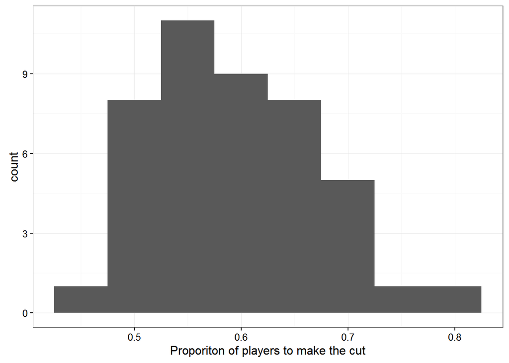

```r
library(dplyr)
library(ggplot2)
masters_year <- masters %>% group_by(year) %>% summarize(prop_cut = mean(made_cut))

ggplot(masters_year, aes(x = prop_cut)) + geom_histogram(binwidth = .05)+
  xlab("Proporiton of players to make the cut") + theme_bw()
```

Across all years, 59.3% of players make the cut. Let’s create a summary for each player.

The following creates a data frame that summarizes the number of times each player has played The Masters, the number of times they made the cut, and the percentage of times they have made the cut.

```r
masters_summary <- masters %>% group_by(player_name) %>%  arrange(year) %>%

                                 mutate(num_events = seq_along(player_name),
                                      cuts_made = cumsum(made_cut),
                                      perc_cuts_made = cuts_made/num_events,
                                      last_event = max(num_events)) %>%

                               filter(num_events == last_event) %>%

                               select(player_name, most_recent_year = year,
                                      cuts_made,
                                      num_events,
                                      perc_cuts_made) %>%

                               ungroup()
```

Which golfers have the best success at making the cut at the masters? Let’s sort the data by percentage of cuts made and look at the first few observations:

| player_name | most_recent_year | cuts_made | num_events | perc_cuts_made |
| --- | --- | --- | --- | --- |
| bert greene | 1972 | 1 | 1 | 1 |
| harry bannerman | 1972 | 1 | 1 | 1 |
| ken still | 1972 | 1 | 1 | 1 |
| james mclean | 1972 | 1 | 1 | 1 |
| larry hinson | 1972 | 1 | 1 | 1 |
| bob rosburg | 1972 | 1 | 1 | 1 |

There you have it, Bert Greene and Harry Bannerman are among those legendary golfers to have the best success at The Masters, having made the cut 100% of the time.

How about the worst:

| player_name | most_recent_year | cuts_made | num_events | perc_cuts_made |
| --- | --- | --- | --- | --- |
| brendon todd | 2015 | 0 | 1 | 0 |
| matias dominguez | 2015 | 0 | 1 | 0 |
| robert streb | 2015 | 0 | 1 | 0 |
| scott harvey | 2015 | 0 | 1 | 0 |
| bradley neil | 2015 | 0 | 1 | 0 |
| gunn yang | 2015 | 0 | 1 | 0 |

Brendan Todd and Matias Dominguez are among those players with the worst Masters records with a cuts made percentage of 0%.

No offence to any of the golfers above, but I doubt anyone believes that those are the best and worst players in Masters cut performance history. The problem is that those golfers have only played The Masters once and either made or didn’t make the cut. This is an issue in estimating proportions in data with very low counts. There is so much uncertainty in the low count data that we don’t trust the estimates.

Here’s a look at the distribution of cuts made percentage:

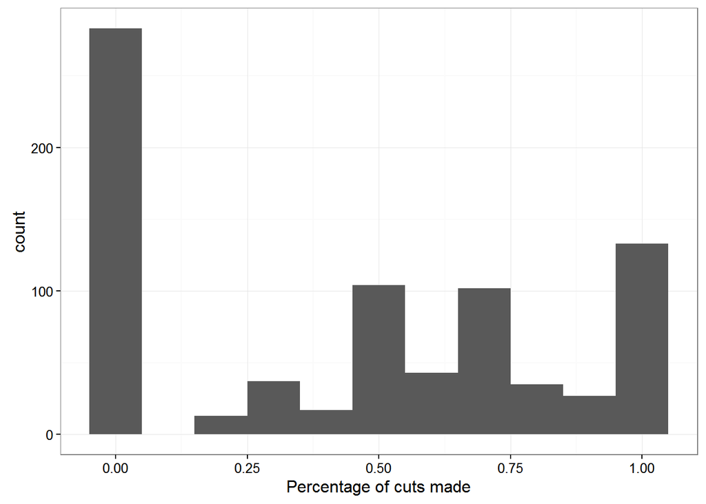

A very high count of 0’s and 1’s. Here is a look at those percentages by the number of events they have played:

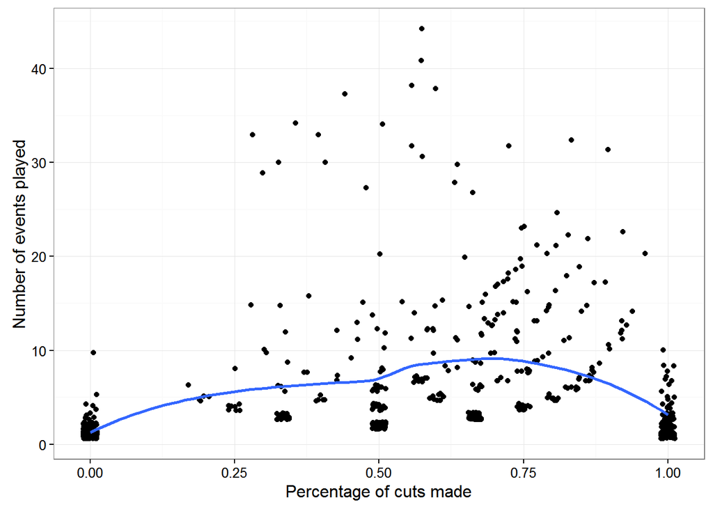

It’s pretty clear that the players with the highest and lowest percentage of cuts made have only played the Masters a handful of times.

## Empirical bayes estimation

This is where empirical bayes comes to the rescue. I am not going to go into much detail because David Robinson’s post mentioned above does a fantastic job of that. But, essentially, empirical bayes works as a shrinkage estimator when you need to estimate a large number of proportions.

In our example, we will use the observed data to estimate the prior belief of making the cut, and then update the estimate of each player’s proportion of success/trials. Players with little data will have their posterior estimates moved towards the prior, while players with much more information will have their posterior estimates further away from the prior (assuming their estimate is much different than the prior).

This is very intuitive. We don’t necessarily trust the estimates of a player who has only played in one or two tournaments as the true measure of their ability, so we put more weight on our prior belief (here, the performance of the whole). We are much more likely to trust the measure of a player who has played in 20+ Masters events, and so we give more weight their estimate.

### Estimating the prior

To estimate the prior probability of making the cut, I filtered the data to only include players who have played at least 5 Masters tournaments. I also removed any remaining players who had either all 0’s or all 1’s for cuts made. A beta distribution was fit to the data using the firdistr function from the [MASS package](https://cran.r-project.org/web/packages/MASS/index.html).

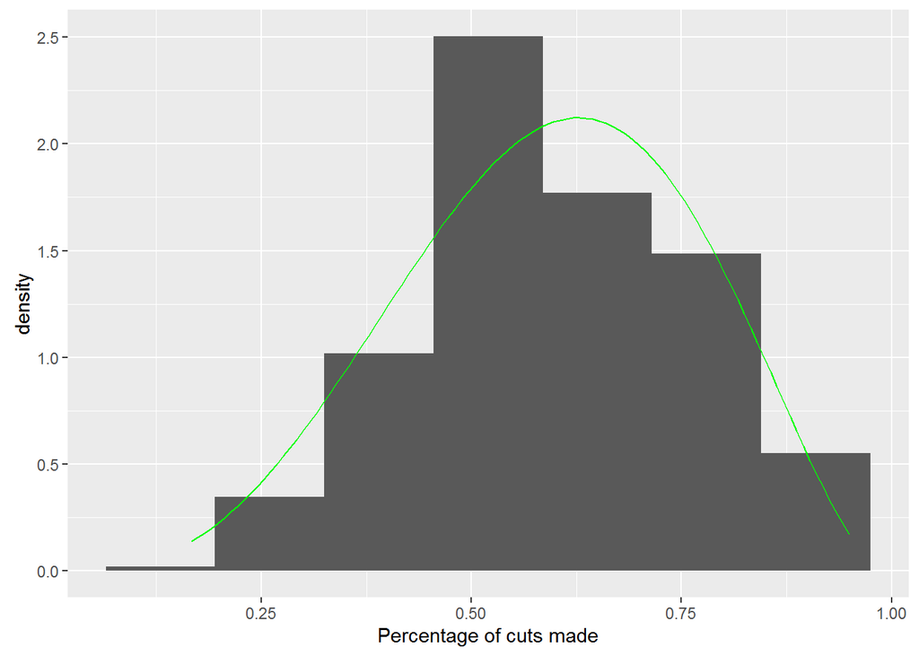

The above fit looks like an okay (but definitely not great) start. A more complicated model might provide better fit. Especially if we want to avoid the subsetting that I did to begin this exercise.

### Update individual estimates with the prior

The model yielded the following estimates for the beta distribution:

$$y=\frac{\alpha_0}{\alpha_0 + \beta_0}= \frac{4.23}{4.23 + 2.92}$$

So, for example, a player who missed his first two cuts at the masters, we would estimate his proportion of cuts made as:

$$\frac{0 + 4.23}{2 + 4.23 + 2.92} = 0.46$$

Quite different than the zero we would estimate otherwise. Below I apply the bayes estimates to every player

```r
masters_eb <- masters_summary %>%
  mutate(eb_estimate = (cuts_made + alpha0) / (num_events + alpha0 + beta0))
```

Now, let’s look at which players have the highest percentage of cuts made:

|  | player_name | most_recent_year | cuts_made | num_events | perc_cuts_made | eb_estimate |
| --- | --- | --- | --- | --- | --- | --- |
| 1 | tiger woods | 2015 | 19 | 20 | 0.95 | 0.85551189217016 |
| 2 | fred couples | 2015 | 28 | 31 | 0.903225806451613 | 0.844750358051892 |
| 3 | phil mickelson | 2015 | 21 | 23 | 0.91304347826087 | 0.836725855249569 |
| 4 | justin rose | 2015 | 10 | 10 | 1 | 0.829582303392924 |
| 5 | bruce lietzke | 1995 | 13 | 14 | 0.928571428571429 | 0.814536451900828 |
| 6 | gene littler | 1980 | 8 | 8 | 1 | 0.807095715317191 |
| 7 | calvin peete | 1987 | 8 | 8 | 1 | 0.807095715317191 |
| 8 | geoff ogilvy | 2015 | 8 | 8 | 1 | 0.807095715317191 |
| 9 | david graham | 1987 | 12 | 13 | 0.923076923076923 | 0.805335627355877 |
| 10 | john huston | 2003 | 12 | 13 | 0.923076923076923 | 0.805335627355877 |

[output cut: 784 more lines]

The above table can be sorted and searched. Look for your favorite player

This makes a lot more sense (poor Arnold Palmer and the lack of data from the 60’s). By pulling rare observations away from the extreme ends of the distribution, we have a better picture of players performance at making the cut at The Masters.

## Future directions/limitations

Perhaps more accurate estimates can be obtained using a regression model. Since the Masters is one of the premiere events on the PGA tour, only the best players get to participate. Playerss that play year after year tend to be the world’s best golfers. I could also imagine a mixture distribution due to the fact that past winners get to play in the Masters for the rest of their life. That is why Arnold Palmer has such a low success rate of making the cut. He’s an old man playing against young pros. More complex methods would also allow us to use the entire data instead of removing outliers before calculating the prior.

In the future I would like to look at the predictive value of this empirical bayes estimator. Does the empirical bayes estimate pf the proportion of cuts made for each player predict making future cuts? I imagine the utility of looking at past results varies from tournament to tournament. Perhaps the predictive value isn’t that great for The Masters where the competition is so high every year.